# Práctica 2 de Estadística

Master Ciencia de Datos UV

Jesús Martínez Leal, Samuel Ortega Mediavilla, Pablo Vicente Martínez

2023-11-06

Como es habitual, cargamos las librerías que necesitamos al inicio del documento.

```r
# Carga de librerías necesarias con pacman
if (!require(pacman)) {
  install.packages("pacman")
  library(pacman)
}
```

```r
pacman::p_load(readr, stringr, tidyr, dplyr, readxl, ggplot2, forcats, MASS, statmod, kableExtra, greekLetters)

set.seed(33)
```

Cargue los datos en el archivo **angles.txt**; los datos han sido generados a partir de una densidad $f(x|k) ∝ sin(x)^k$ en el intervalo $[0, π]$ $(f(x|k) = 0$ fuera del intervalo $[0, π]$). Notación: ∝ significa *proporcional a*, lo que significa que $f(x|k) = C_k \sin(x)^k$, donde $C_k$ es una constante de normalización apropiada.

```r
angles <- readLines(con = "./data/angles.txt")
angles <- angles[-1]
a <- unlist(strsplit(angles, split = " "))
a <- matrix(a, ncol = 2 ,byrow = T)
a <- a[, 2]
a <- as.numeric(a)
```

# Ejercicio 1. Una densidad para ángulos

## Ejercicio 1.0

**Enunciado**

¿Cómo puede calcular la constante de normalización $C_k $?

**Resolución**

Para calcular la constante de normalización $C_k$ tenemos que normalizar la integral de la densidad de probabilidad en nuestro dominio de definición a la unidad, para que pueda interpretarse como probabilidad.

$$\int_{0}^\pi C_k \sin(x)^k dx = 1$$

## Ejercicio 1.1

**Enunciado**

¿El modelo es paramétrico? ¿Cuáles son los parámetros del modelo?

**Resolución**

El modelo es paramétrico porque se puede parametrizar con un número finito de variables. En este caso el número de parámetros es 1: **k**.

## Ejercicio 1.2

**Enunciado**

Escriba la función del logaritmo negativo de la verosimilitud del modelo e impleméntela en una función de R.

La función de verosimilitud es:

$$\mathcal{L}_n(k) = \prod_{i = 1}^n C_k
\sin{(x_i)}^k$$

Y por tanto, la función del logaritmo negativo de la verosimilitud queda de la forma:

$$ℓ_n(k) = -\sum_{i = 1}^n \left(\ln(C_k)
+ k·\ln(\sin(x_i))\right)$$

Y se implementaría en R como sigue:

```r
C_norm <- function(k, obs) sin(obs)**k

l_n <- function(k, obs) -sum(log(1 / integrate(C_norm, lower = 0, upper = 3.14, k = k)$value) + k*log(sin(obs)))
```

## Ejercicio 1.3

**Enunciado**

Utilice un método de optimización numérica para encontrar el estimador de máxima verosimilitud

**Resolución**

Podemos hacer uso de la función **optimize**.

```r
k_opt <- optimize(l_n, obs = a, lower = 5, upper = 20)
```

Vemos que el valor para el estimador es k = 11.4003881

## Ejercicio 1.4

**Enunciado**

Grafique el histograma de los datos y la densidad correspondiente al estimador de máxima verosimilitud.

**Resolución**

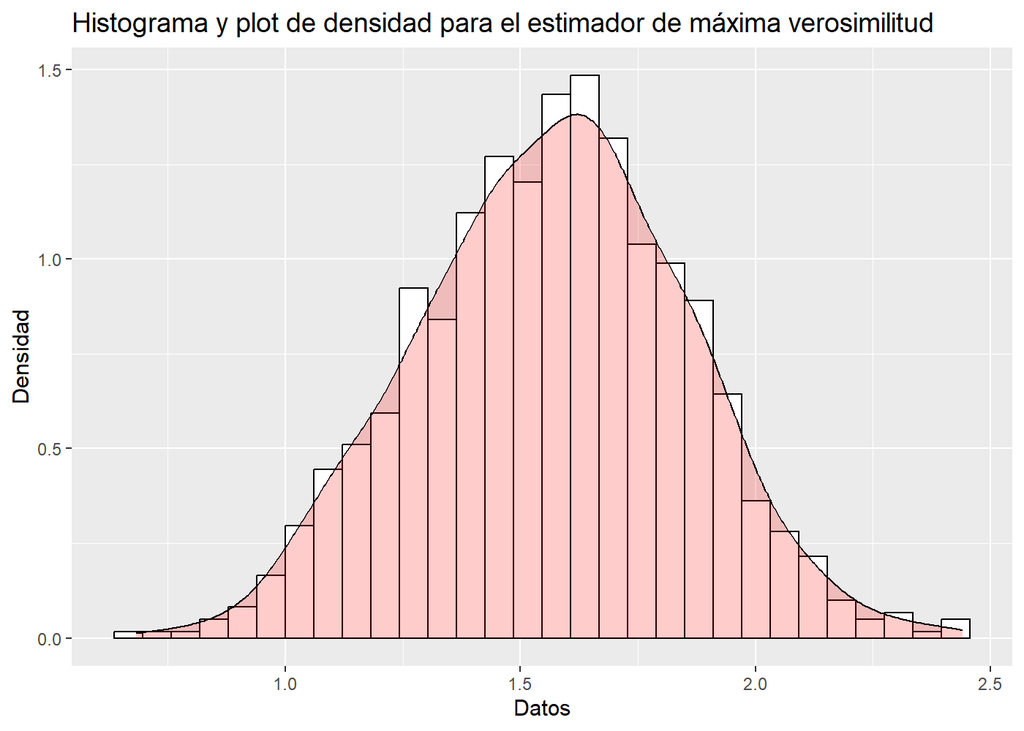

```r
df_a <- data.frame(a)

ggplot(df_a, aes(a)) +
  geom_histogram(aes(y = after_stat(density)), colour = "black", fill = "white") +
  geom_density(alpha = .2, fill="red") +
  labs(title = "Histograma y plot de densidad para el estimador de máxima verosimilitud", x = "Datos", y = "Densidad")
```

## Ejercicio 1.5

**Enunciado**

Construye un intervalo de confianza del 99% para k basado en los datos en el archivo angles.txt. ¿Cómo puedes estimar el error estándar?

**Resolución**

```r
#Método de bootstrap para sacar distribución de k
v_sample <- replicate(1000, {
  aux <- sample(df_a$a, size = 1000, replace = T)
  kest <- optimize(l_n, obs = aux, lower = 5, upper = 20)$minimum

  return(kest)
})

#Intervalo normal
k_std <- sd(v_sample)
alpha <- 0.01
za2 <- qnorm(alpha / 2, lower.tail = F)
k_trust <- k_opt$minimum + c(-1,1)*za2*k_std

#Intervalo de percentil
k_perct <- quantile(v_sample, probs = c(alpha/2, 1-alpha/2))
```

## Ejercicio 1.6

**Enunciado**

Prueba si $k > 10$ a un nivel de confianza α = 0.05 para los datos en el archivo angles.txt (puedes utilizar la prueba de Wald H0 : k ≤ 10).

**Resolución**

```r
alpha <- 0.05
k_0 <- 10
w <- abs((k_opt$minimum - k_0) / k_std)
p_value <- 2 * pnorm(-abs(w))

if (p_value < alpha){
cat("Dado que el p-value de la prueba de Wald es", p_value, "podemos rechazar la hipótesis nula (H0 : k ≤ 10)")
} else {
  cat("No se puede rechazar la hipótesis nula.")
}
```

```
Dado que el p-value de la prueba de Wald es 0.009365495 podemos rechazar la hipótesis nula (H0 : k ≤ 10)
```

# Ejercicio 2. Un estudio sobre datos de neuronas

Las neuronas funcionan generando y propagando potenciales de acción, llamados “spikes”. El intervalo de tiempo entre dos spikes adyacentes, o inter-spikes interval (ISI), se utiliza a menudo en la neurocicencia computacional. En el archivo *neuronspikes.txt* puedes encontrar algunas mediciones de ISI.

Carga los datos en R y completa los siguienes ejercicios:

```r
isidata <- read.table("./data/neuronspikes.txt", col.names = "isi")
```

## Ejercicio 2.1.

**Enunciado**

Si asumimos que las observaciones de ISI son i.i.d. siguen una distribución exponencial con parámetro $\lambda$, calcule el estimador de máxima verosimilitud de $\lambda$.

**Resolución**

Sea $X_1, ..., X_n \sim \exp({\lambda})$ ($\lambda$ > 0) donde sabemos que la PDF es $f(x|\lambda) = \lambda \exp(-\lambda x)$.

La verosimilitud por definición:

$$\mathcal{L}_n(\lambda) = \prod_{i = 1}^n
f(X_i|\lambda) = \prod_{i = 1}^n \lambda \exp(-\lambda X_i)$$

Nos será más sencillo trabajar con la función log-verosoimiltud por las propiedades de la función exponencial:

$$ℓ_n(\lambda) =
\ln{\mathcal{L_n(\lambda)}} = \sum_{i = 1}^n (\ln(\lambda) + (-\lambda
X_i)) = n \ln(\lambda) - \lambda \sum_{i = 1}^n(X_i)$$
Procedemos a calcular el valor de $\lambda$ que permite maximizar esta función, requiriendo acudir al cálculo diferencial.

Igualamos la primera derivada a cero para hallar los puntos críticos:

$$\frac{dℓ_n}{d\lambda} =
\frac{n}{\lambda} - \sum_{i = 1} ^n (X_i) = 0$$
Obtenemos despejando para $\lambda$:

$$\lambda = \frac{n}{\sum_{i = 1}^n} =
\frac{1}{\bar{X}}$$
Para verificar que es un máximo acudimos al criterio de la segunda derivada, que nos ofrece:

$$\frac{d^2ℓ_n}{d\lambda^2} = -
\frac{n}{\lambda ^2},$$
de tal forma que se ve que es siempre negativo dada nuestra restricción en el parámetro $\lambda$ de ser positivo.

Podemos entonces asegurar que el estimador de máxima verosimilitud de nuestro parámetro es:

$$\hat{\lambda} = \frac{1}{\bar{X}}$$
Así pues, tendremos:

```r
lambda_hat <- 1 / mean(isidata$isi)
cat("El parámetro estimado es λ =", lambda_hat, "\n")
```

```
El parámetro estimado es λ = 1.146891
```

```r
mllk <- function(rate, data) {
  -sum((dexp(data, rate = rate, log = TRUE)))
}

optimize(f = mllk, data = isidata$isi, interval = c(0, 10))
```

```
$minimum
[1] 1.146881

$objective
[1] 269.2388
```

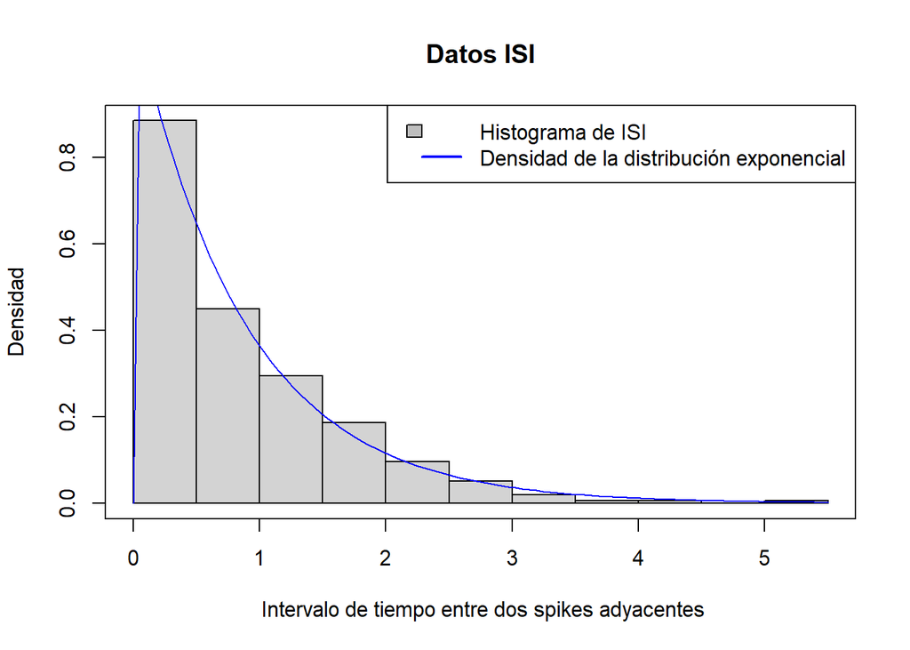

```r
rate_num_est <- optimize(f = mllk, data = isidata$isi, interval = c(0, 10))$minimum

hist(isidata$isi, breaks = 10, probability = TRUE, xlab = " Intervalo de tiempo entre dos spikes adyacentes",
    ylab = "Densidad", main = "Datos ISI")
curve(dexp(x, rate_num_est), add = TRUE, col = "blue")
box()
legend_labels <- c("Histograma de ISI", "Densidad de la distribución exponencial")
legend("topright", legend = legend_labels, fill = c("gray", NA), border = c("black", NA), lwd = c(NA,
    2), col = c(NA, "blue"))
```

Con una función implementada en R directamente nos ahorraríamos esto:

```r
data <- isidata$isi

# Ajuste de los datos a función que especifiquemos
fit <- fitdistr(data, "exponential")

# Obtener parámetros
estimated_rate <- fit$estimate

cat("El parámetro estimado es λ =", estimated_rate, "\n")
```

```
El parámetro estimado es λ = 1.146891
```

## Ejercicio 2.2

**Enuncicado**

Ahora, asumiendo que las observaciones de ISI son i.i.d. y siguen una distribución gamma con paráemtros $\alpha$ (*shape*) y $\beta$ (*rate*), encuentre los estimadores de máxima verosimiltud de los parámetros $\alpha$ y $\beta$.

**Resolución**

Sacaremos numéricamente estos estimadores utilizando una función implementada en R:

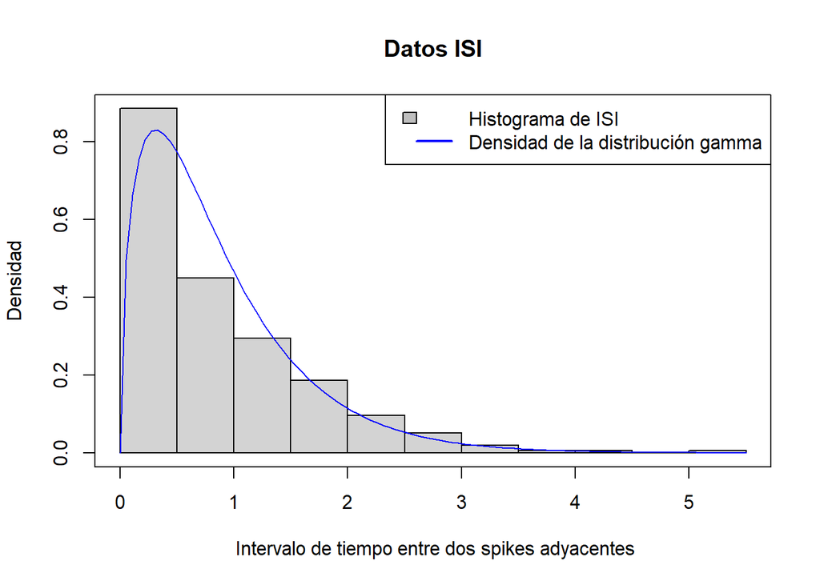

```r
mllk <- function(params, data) {
  shape <- params[1]
  rate <- params[2]
  -sum(dgamma(data, shape = shape, rate = rate, log = TRUE))
}

params <- optim(c(1, 1), f = mllk, data = isidata$isi, method = c("Nelder-Mead"))$par

hist(isidata$isi, breaks = 10, probability = TRUE, xlab = " Intervalo de tiempo entre dos spikes adyacentes",
    ylab = "Densidad", main = "Datos ISI")
curve(dgamma(x, shape = params[1], rate = params[2]), add = TRUE, col = "blue")
box()
legend_labels <- c("Histograma de ISI", "Densidad de la distribución gamma")
legend("topright", legend = legend_labels, fill = c("gray", NA), border = c("black", NA), lwd = c(NA,
    2), col = c(NA, "blue"))
```

De nuevo, podríamos hacerlo con una función implementada en una librería directamente.

```r
data <- isidata$isi

# Ajuste de los datos a función que especifiquemos

fit <- fitdistr(data, "gamma")

# Obtener parámetros
estimated_shape <- fit$estimate["shape"]
estimated_rate <- fit$estimate["rate"]

cat("El valor de shape estimado es:", estimated_shape)
```

```
El valor de shape estimado es: 1.562453
```

```r
cat("\nEl valor de rate estimado es:", estimated_rate)
```

```
El valor de rate estimado es: 1.791955
```

## Ejercicio 2.3

**Enunciado**

Para la distribución gamma, conocemos las fórmulas de la media y la varianza, como sigue,

$$\mathbb{E} (X) = \frac{\alpha}{\beta}$$

$$\mathbb{V} (X) =
\frac{\alpha}{\beta^2}$$

Tratar de encontrar el estimador de momentos de $\alpha$ y $\beta$. El estimador de momentos puede utilizarse para encontrar la primera estimación y para inicializar el algoritmo iterativo de MLE.

**Resolución**

Tenemos las dos primeras ecuaciones del método de los momentos, por lo que tenemos lo siguiente. Si introducimos la primera ecuación en la segunda:

$$\beta = \frac{\mathbb{E (X)}}{\mathbb{V
(X)}}$$
Esto en R sería:

```r
beta_est <- mean(isidata$isi) / var(isidata$isi)
beta_est
```

```
[1] 1.472556
```

Para $\alpha$ solamente resta sustituir:

$$\alpha = \beta \ \mathbb{E (X)}$$

```r
alpha_est <- beta_est * mean(isidata$isi)
alpha_est
```

```
[1] 1.283954
```

Estos valores se utilizan a continuación como valores iniciales para realizar el proceso iterativo que calcula los mejores estimadores MLE.

```r
mllk <- function(params, data) {
  shape <- params[1]
  rate <- params[2]
  -sum(dgamma(data, shape = shape, rate = rate, log = TRUE))
}

params <- optim(c(alpha_est, beta_est), f = mllk, data = isidata$isi, method = c("Nelder-Mead"))$par

params
```

```
[1] 1.562585 1.792009
```

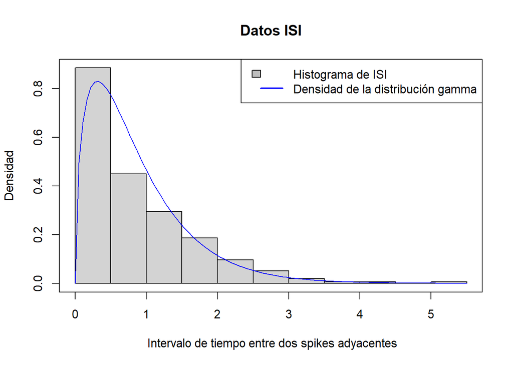

```r
hist(isidata$isi, breaks = 10, probability = TRUE, xlab = " Intervalo de tiempo entre dos spikes adyacentes",
    ylab = "Densidad", main = "Datos ISI")
curve(dgamma(x, shape = params[1], rate = params[2]), add = TRUE, col = "blue")
box()
legend_labels <- c("Histograma de ISI", "Densidad de la distribución gamma")
legend("topright", legend = legend_labels, fill = c("gray", NA), border = c("black", NA), lwd = c(NA,
    2), col = c(NA, "blue"))
```

Vemos cómo la estimación ofrecida por el método de máxima verosimilitud converge, al igual que cuando en el apartado 2.2 se introdujo manualmente el valor para el estimador inicial de los parámetros.

## Ejercicio 2.4

**Enunciado**

La distribución exponencial es un caso especial de la distribución gamma cuando el parámetro de forma es igual a 1. Verifica este hecho gráficamente en R.

**Resolución**

Una búsqueda simple en Wikipedia de *Gamma distribution* nos permite conocer la PDF de esta, siendo:

$$f(x) = \frac{\beta ^
\alpha}{\Gamma(\alpha)} x ^{\alpha - 1} * \exp(-\beta x)$$

Automáticamente, si particularizamos para el factor *shape* ($\alpha$) que sea igual a 1 obtenemos la expresión para la PDF de la distribución exponencial, ($\Gamma$ (1) = (1 - 1) ! = 0! = 1, $x ^ 0 = 1, x > 0$).

Para ver esto de manera gráfica hacemos un plot donde se muestra la distribución exponencial junto con varias distribuciones gamma, donde vamos cada vez acercándonos más a la unidad para el parámetro de forma.

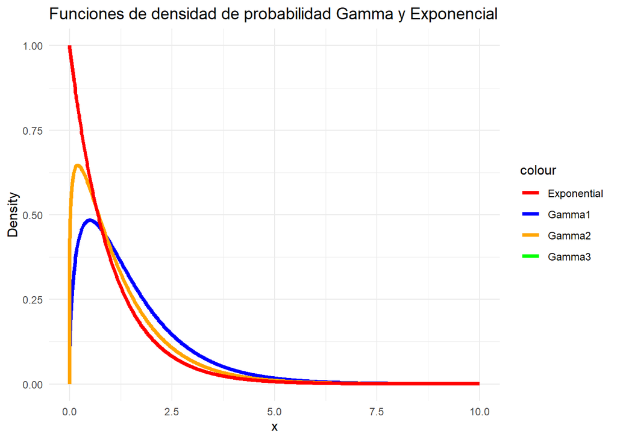

```r
shape_gamma <- c(1.5, 1.2, 1)
rate_gamma <- c(1, 1, 1)
rate_exp <- 1
x <- seq(0, 10, by = 0.01)

df <- data.frame(x = x,
                 pdf_gamma = dgamma(x, shape_gamma[1], rate_gamma[1]),
                 pdf_gamma2 = dgamma(x, shape_gamma[2], rate_gamma[2]),
                 pdf_gamma3 = dgamma(x, shape_gamma[3], rate_gamma[3]),
                 pdf_exp = dexp(x, rate_exp))

ggplot(df, aes(x = x)) +
  geom_line(aes(y = pdf_gamma, color = "Gamma1"), size = 1.5) +
  geom_line(aes(y = pdf_gamma2, color = "Gamma2"), size = 1.5) +
  geom_line(aes(y = pdf_gamma3, color = "Gamma3"), size = 1.5) +
  geom_line(aes(y = pdf_exp, color = "Exponential"), size = 1.5) +
  labs(y = "Density", x = "x") +
  ggtitle("Funciones de densidad de probabilidad Gamma y Exponencial") +
  scale_color_manual(values = c("Gamma1" = "blue", "Gamma2" = "orange", "Gamma3" = "green", "Exponential" = "red")) +
  theme_minimal() +
  theme(legend.position = "right")
```

Puede apareciarse como Gamma3 parece desaparecer. Esta posee el parámetro $\alpha = 1$ y el mismo valor del parámetro de *rate* que la exponencial, hallándose entonces solapada con la curva exponencial roja. Esto es inmediato de comprobar si se grafica la curva resta para su dominio de definición.

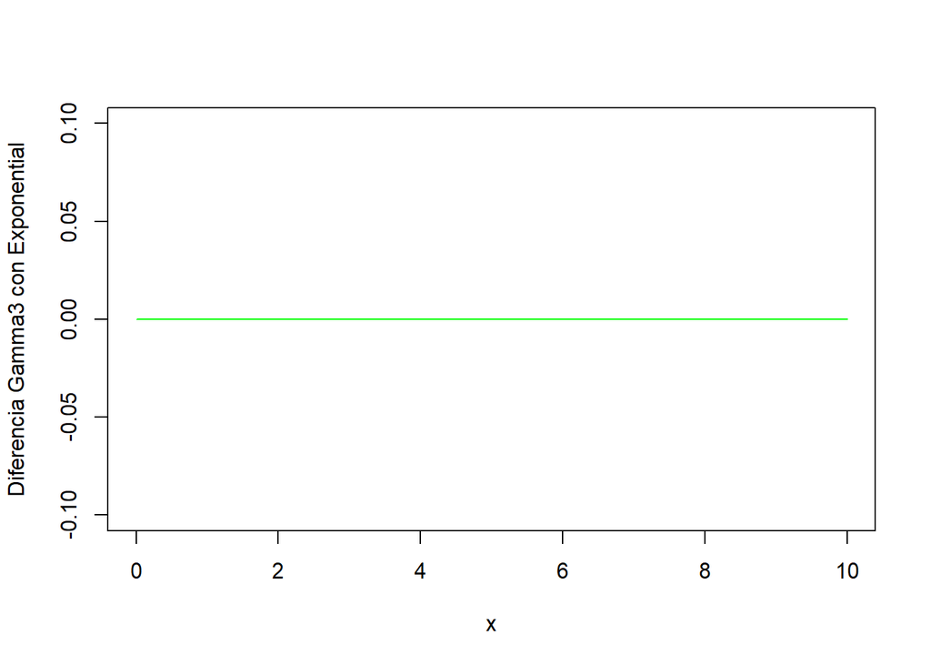

```r
plot(x, df$pdf_exp - df$pdf_gamma3, xlim = c(0, 10), ylim = c(-0.1, 0.1), type = "l", xlab = "x", ylab = "Diferencia Gamma3 con Exponential", col = "green")
```

## Ejercicio 2.5

**Enunciado**

Dado que el modelo exponencial está anidado en el modelo gamma, podemos realizar la prueba de razón de verosimilitud (likelihood-ratio test) para seleccionar entre los dos modelos. Realiza la prueba de razón de verosimilitud en R y reporta el valor de p resultante.

**Resolución**

$H_0$: el modelo $\mathcal{M}_1$ es suficiente para describir los datos.

```r
exp_model <- fitdistr(data, "exponential")
gamma_model <- fitdistr(data, "gamma")

lr <- -2 * (exp_model$loglik - gamma_model$loglik)
lr
```

```
[1] 33.07526
```

```r
p_val <- pchisq(lr, df = 1, lower.tail = FALSE) # lower.tail en FALSE para que coja desde ese valor hasta el inf
cat("Valor del p valor: ", p_val, "\n")
```

```
Valor del p valor:  8.865953e-09
```

```r
alpha <- 0.05

if (p_val < alpha){
  print("Se rechaza la hipótesis nula.")
} else{
  print("No puede rechazarse la hipótesis nula.")
}
```

```
[1] "Se rechaza la hipótesis nula."
```

# Ejercicio 3

**Enunciado**

Además de las distribuciones exponencial y gamma, la distribución inversa Gaussiana es otro modelo ampliamente utilizado para los intervalos entre eventos. Describe el tiempo de primer paso de un movimiento browniano unidimensional sujeto a un valor umbral fijo. La función de densidad de probabilidad se define como:

$$f(x|\mu, \lambda) =
\left( \frac{\lambda}{2\pi x^3} \right)^{1/2} \cdot
\exp{\left( \frac{-\lambda(x-\mu )^ {2}}{2\mu^2 x} \right)}$$

## Ejercicio 3.1

**Enunciado**

Escriba (analíticamente) la fórmula para el logaritmo de la verosimilitud dadas n observaciones i.i.d.

**Resolución**

La función de log-verosimilitud es

$$\begin{align}
l_n (\mu, \lambda) =
\ln{\left[ \mathcal{L}_n (\mu, \lambda) \right]} =
\ln{\left[\prod_{i = 1}^n \mathscr{f}(x_i|\mu, \lambda) \right]} =
\sum_{i = 1}^n \ln{\left[ \mathscr{f}(x_i|\mu, \lambda) \right]} =
\sum_{i = 1}^n \ln{\left[
\left( \frac{\lambda}{2\pi x_i^3} \right)^{1/2} \cdot
\exp{\left( \frac{-\lambda(x_i-\mu )^ {2}}{2\mu^2 x_i} \right)}
\right]} = \\
\sum_{i = 1}^n \left\{ \ln{\left[
\left( \frac{\lambda}{2\pi x_i^3} \right)^{1/2} \right]} -
\frac{-\lambda(x_i-\mu )^ {2}}{2\mu^2 x_i} \right\} =
\sum_{i = 1}^n \left[ \frac{1}{2} \ln{
\left( \frac{\lambda}{2\pi x_i^3} \right)} -
\frac{\lambda(x_i-\mu )^ {2}}{2\mu^2 x_i} \right]
\end{align}$$

## Ejercicio 3.2

**Enunciado**

Intente derivar la fórmula de los estimadores de máxima verosimilitud para $\mu$ y $\lambda$ (si no es capaz, vaya al punto 3.4).

**Resolución**

La derivada respecto de $\mu$ es:

$$\frac{\partial}{\partial \mu} l_n (\mu, \lambda) =
\sum_{i=1}^n \left[
\frac{1}{2} \ln{\left( \frac{\lambda}{2\pi x_i^3} \right)} -
\frac{\lambda(x_i-\mu)}{\mu^2 x_i} \right]$$

La derivada respecto de $\lambda$ es:

$$\frac{\partial}{\partial \lambda} l_n (\mu, \lambda) =
\sum_{i=1}^n \left[ \frac{\lambda}{2} -
\frac{\left(x_i-\mu\right)^2}{2\mu^2 x_i} \right] =
n\frac{\lambda}{2} - \sum_{i=1}^n \frac{\left(x_i-\mu\right)^2}{2\mu^2
x_i}$$
Para hallar los puntos críticos igualaríamos a 0 este sistema de ecuaciones y trataríamos de analizar cuáles son los máximos, como se indica en el siguiente ejercicio.

## Ejercicio 3.3

**Enunciado**

Aplique los estimadores de MLE en el paso anterior a los datos ISI experimentales, es decir, calcule las estimaciones teóricas de $\mu$ y $\lambda$ para los datos ISI.

**Resolución**

Resolviendo el sistema de ecuaciones y verificando la condición de que son máximos se obtendría finalmente:

$$\hat{\mu} = \frac{\sum_{i=n}^n x_i}{n} \ , \
\frac{1}{\hat{\lambda}} =
\frac{1}{n} \sum_{i=n}^n \left( \frac{1}{x_i} - \frac{1}{\hat{\mu}}
\right)$$
Aplicando directamente las expresiones teóricas a nuestros datos obtenemos:

```r
isi <- read.table("./data/neuronspikes.txt", col.names = "isi")[[1]]

mu_est <- sum(isi) / length(isi)

lambda_est <- ( sum(1 / isi - 1 / mu_est) / length(isi) ) ^ (-1)
```

Los resultados obtenidos para los estimadores son: $\hat{\mu} =$ 0.8719221 y $\hat{\lambda} =$ 0.8679884.

## Ejercicio 3.4

**Enunciado**

Encuentre los estimadores de máxima verosimilitud utilizando métodos numéricos.

**Resolución**

Usamos la función `dinvgauss()` del paquete `statmod`.

```r
mllk <- function(params, data) {
  mean <- params[1]
  shape <- params[2]
  -sum(dinvgauss(data, mean = mean, shape = shape, log = TRUE))
}

num_est <- optim(c(1, 1), f = mllk, data = isi, method = c("Nelder-Mead"))

results <- data.frame(
  data = matrix(
    data = c(mu_est, lambda_est, num_est$par),
    ncol = 2,
    byrow = TRUE))
rownames(results) <- c("Teórico", "Numérico")
colnames(results) <- c(greeks("mu"), greeks("lambda"))

results %>%
  kbl(caption = "Resultados de los estimadores.") %>%
  kable_classic(full_width = F, html_font = "Cambria")
```

Resultados de los estimadores.

|  | μ | λ |
| --- | --- | --- |
| Teórico | 0.8719221 | 0.8679884 |
| Numérico | 0.8718732 | 0.8679736 |

## Ejercicio 3.5

**Enunciado**

Grafique la densidad estimada de la distribución inversa Gaussiana sobre el histograma de los datos ISI y con la estimación de densidad de kernel. Si puede encontrar estimadores de momentos de los parámetros, puede usarlos como puntos iniciales para la optimización numérica.

**Resolución**

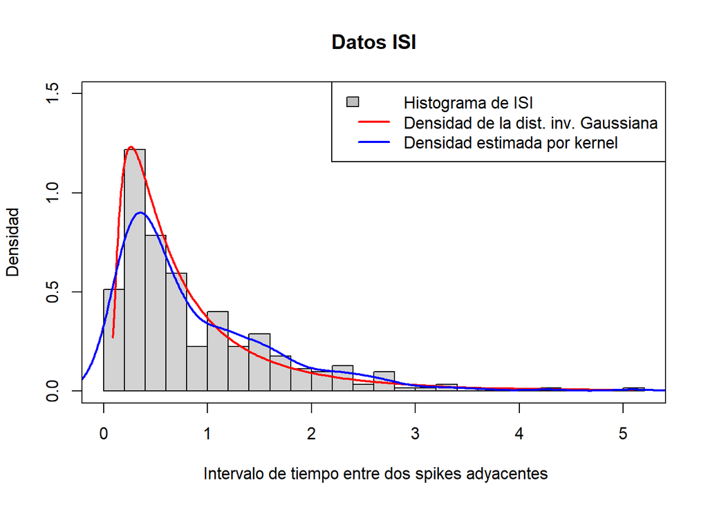

```r
hist(isi, breaks = 20, freq = FALSE, ylim = c(0, 1.5),
     xlab = " Intervalo de tiempo entre dos spikes adyacentes",
     ylab = "Densidad", main = "Datos ISI")
lines(isi,dinvgauss(isi, mu_est, lambda_est), col = "red", lwd = 2)
density_est <- density(isi, bw = "nrd0", kernel = c("gaussian"))
lines(density_est, col = "blue", lwd = 2)
box()

legend_labels <- c("Histograma de ISI", "Densidad de la dist. inv. Gaussiana", "Densidad estimada por kernel")
legend("topright", legend = legend_labels,
       fill = c("gray", NA, NA),
       border = c("black", NA, NA),
       lwd = c(NA, 2, 2),
       col = c(NA, "red", "blue"))
```

# Ejercicio 4. Conjunto de datos de células cerebrales

Continuamos el estudio del conjunto de datos de células cerebrales del Instituto Allen.

```r
path <- "./data/cell_types.csv"
cell <- read.csv(path, sep = ",", dec = ".", na.strings = "")
```

## Ejercicio 4.1

**Enunciado**.

Encuentra numéricamente las estimaciones MLE de los parámetros de la distribución log-normal para las observaciones de *ramp spike time* (en R está implementada la log-normal dlnorm).

**Resolución**.

De manera análoga a como se ha procedido en ejercicios anteriores estimamos estos parámetros con la siguiente algoritmia:

```r
mllk_lnorm <- function(params, data) {
  meanlog <- params[1]
  sdlog <- params[2]
  -sum(dlnorm(data, meanlog = meanlog, sdlog = sdlog, log = TRUE)) # usamos dlnorm para log-normal
}
```

```r
ramp <- na.omit(cell$ef__peak_t_ramp) # quito los NA para que no haya problemas

paramsLognormal <- optim(c(6, 4), f = mllk_lnorm, data = ramp, method = c("Nelder-Mead"))$par
names(paramsLognormal) <- c("meanlog", "sdlog")
print(paramsLognormal)
```

```
  meanlog     sdlog
1.6687659 0.6056156
```

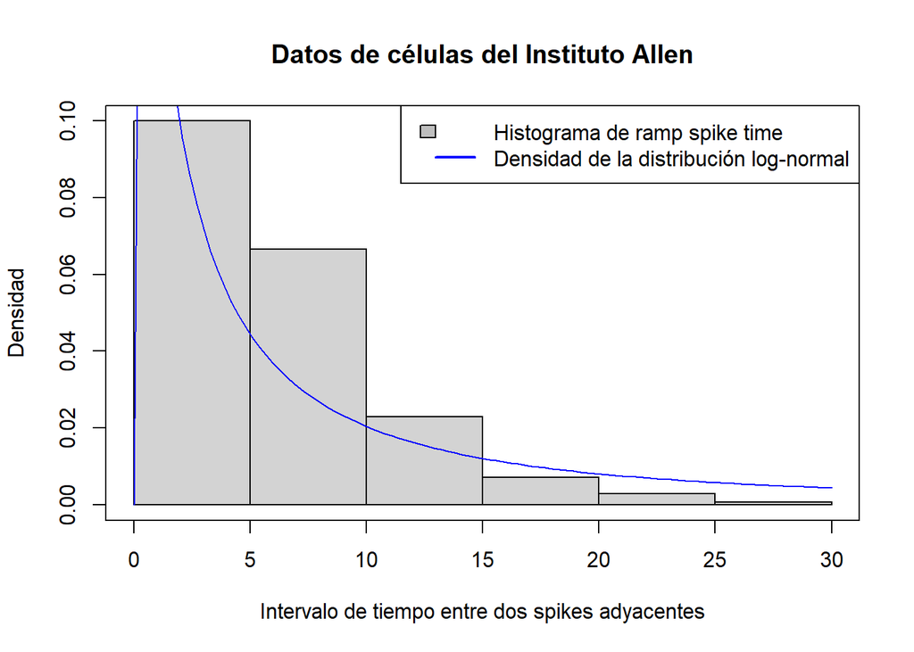

```r
hist(ramp, breaks = 10, probability = TRUE, xlab = "Intervalo de tiempo entre dos spikes adyacentes",
    ylab = "Densidad", main = "Datos de células del Instituto Allen")
curve(dlnorm(x, meanlog = params[1], sdlog = params[2]), add = TRUE, col = "blue")
box()
legend_labels <- c("Histograma de ramp spike time", "Densidad de la distribución log-normal")
legend("topright", legend = legend_labels, fill = c("gray", NA), border = c("black", NA), lwd = c(NA,
    2), col = c(NA, "blue"))
```

## Ejercicio 4.2

**Enunciado**.

Como su nombre sugiere, la distribución log-normal está relacionada con la distribución Gaussiana. En particular, si $X$ es una distribución lognormal con parámetros μ y σ, entonces log(X) es una distribución normal con valor medio μ y desviación estándar σ. Ahora probaremos este hecho empíricamente. Transforma las observaciones de ”ramp spike time” utilizando el logaritmo y luego obtén la MLE de los parámetros para una distribución Gaussiana utilizando los datos transformados. Comprueba que los resultados que obtengas sean iguales a las estimaciones MLE obtenidas numéricamente en el punto 4.1.

**Resolución**

```r
mllk_norm <- function(params, data) {
  mean <- params[1]
  sd <- params[2]
  -sum(dnorm(data, mean = mean, sd = sd, log = TRUE))
}
```

```r
logramp <- log(ramp) # transformo los datos con el logaritmo

paramsNormal <- optim(c(6, 4), f = mllk_norm, data = logramp, method = c("Nelder-Mead"))$par
names(paramsNormal) <- c("mean", "sd")
print(paramsNormal)
```

```
     mean        sd
1.6688832 0.6055671
```

```r
# Se obtienen resultados prácticamente iguales?
# Calculamos el error relativo

tol <- 1e-3

if(all(abs(paramsNormal - paramsLognormal) / paramsNormal < c(tol, tol)) == TRUE) {cat("Se ha probado empíricamente que los resultados obtenidos son iguales (o casi iguales por temas numéricos).")}
```

```
Se ha probado empíricamente que los resultados obtenidos son iguales (o casi iguales por temas numéricos).
```

## Ejercicio 4.3

**Enunciado**

Encuentra ahora las estimaciones MLE de los parámetros de la distribución log-normal utilizando solo las observaciones de seres humanos masculinos y seres humanos femeninos. Grafica las dos densidades log-normal obtenidas en la misma gráfica.

**Resolución**

Filtramos primeramente haciendo uso de dplyr el dataframe para tener las observaciones de *males* y *females* por separado.

```r
cell_male <- cell %>%
  filter(donor__sex == "Male")

cell_female <- cell %>%
  filter(donor__sex == "Female")
```

Pasamos ahora a la resolución del ejercicio, análogamente a como se hizo en apartados anteriores.

```r
ramp_male <- na.omit(cell_male$ef__peak_t_ramp)
ramp_female <- na.omit(cell_female$ef__peak_t_ramp)


paramsLognormal_male <- optim(c(6, 4), f = mllk_lnorm, data = ramp_male, method = c("Nelder-Mead"))$par
paramsLognormal_female <- optim(c(6, 4), f = mllk_lnorm, data = ramp_female, method = c("Nelder-Mead"))$par

parameters <- data.frame(
  data = matrix(
    data = c(paramsLognormal_male, paramsLognormal_female),
    ncol = 2,
    byrow = TRUE))
colnames(parameters) <- c("meanlog", "sdlog")
rownames(parameters) <- c("male", "female")

parameters %>%
  kbl(caption = "Resultados de los estimadores.") %>%
  kable_classic(full_width = F, html_font = "Cambria")
```

Resultados de los estimadores.

|  | meanlog | sdlog |
| --- | --- | --- |
| male | 1.835501 | 0.7256142 |
| female | 1.874023 | 0.7147675 |

Por último, graficamos:

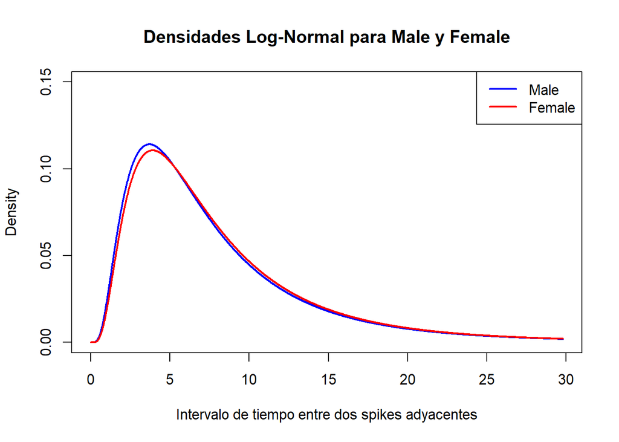

```r
x <- seq(0, max(ramp_male), by = 0.01)

plot(x, dlnorm(x, meanlog = paramsLognormal_male[1], sdlog = paramsLognormal_male[2], ), type = "l", col = "blue", lwd = 2, xlab = "Intervalo de tiempo entre dos spikes adyacentes", ylab = "Density", xlim = c(0, max(ramp_male)), ylim = c(0, 0.15))
lines(x, dlnorm(x, meanlog = paramsLognormal_female[1], sdlog = paramsLognormal_female[2]), col = "red", lwd = 2)

legend("topright", legend = c("Male", "Female"), col = c("blue", "red"), lwd = 2)
title("Densidades Log-Normal para Male y Female")
```

Vemos que a simple vista la diferencia es bastante escasa.

## Ejercicio 4.4

**Enunciado**

Estima el error estándar del estimador MLE de $\mu$ para la distribución log-normal aplicada a los datos de *ramp spike time*.

**Resolución**

Haremos uso del método de bootstrap, de tal forma que generaremos un muestreo (con reemplazo) de n puntos de nuestra muestra. Con cada una de estas muestras se halla el parámetro estimado con MLE, de tal forma que obtenemos una distribución de ellos al final, con los que podemos tener una estadística.

```r
n <- length(ramp)

# Método de bootstrap para sacar distribución de mu

mu_sample <- replicate(100, {
  aux <- sample(ramp, size = length(ramp), replace = T)
  params_i <- optim(c(1.5, 0.5), f = mllk_lnorm, data = aux, method = c("Nelder-Mead"))$par[1]

  return(params_i)
})

# Error estándar para mu tomada como la desviación estándar de los valores de mu_sample

mu_se <- sd(mu_sample)
cat("El error estándar para el estimador vale", mu_se)
```

```
El error estándar para el estimador vale 0.01135326
```

## Ejercicio 4.5

**Enunciado**

Obtén un intervalo de confianza del 95% para el parámetro $\mu$ (prueba diferentes métodos).

**Resolución**

Podemos estimarlo con 2 métodos diferentes utilizando bootstrap:

- Con intervalo normal:

$$(\hat{\theta} - z_{\alpha/2}
\hat{se}_{boot}, \ \hat{\theta} + z_{\alpha/2} \hat{se}_{{boot}} )$$

```r
alpha <- 0.05
za2 <- qnorm(alpha / 2, lower.tail = F)

mu_trust <- paramsLognormal[1] + c(-1, 1) * za2 * mu_se
cat("(", mu_trust[1], ",", mu_trust[2], ")", "es el intervalo de confianza del 95% para µ.")
```

```
( 1.646514 , 1.691018 ) es el intervalo de confianza del 95% para µ.
```

- Con intervalo de percentil bootstrap:

$$C_n = (\theta^{*}_{\alpha / 2},
\theta^{*}_{1 - \alpha / 2}),$$
donde $\theta^*_{\alpha / 2}$ es el cuantil empírico obtenido a partir de la muestra bootstrap de $\hat{\theta}^{*}.$

```r
mu_perct <- quantile(mu_sample, probs = c(alpha / 2, 1- alpha / 2))
cat("(", mu_perct[1], ",", mu_perct[2], ")", "es el intervalo de confianza del 95% para µ.")
```

```
( 1.645961 , 1.688916 ) es el intervalo de confianza del 95% para µ.
```

# Ejercicio 5. Quakes data y modelos de mezcla Gaussianos

**Enunciado**

En este problema, analizaremos el conjunto de datos **quakes**, que contiene información sobre 1000 terremotos que ocurrieron cerca de Fiji desde 1964. Es un conjunto de datos de 1000 $\times$ 5 observaciones y 5 columnas. **lat**, **long** y **depth** son la latitud, longitud y la profundidad (km) de la ubicación del terremoto, correspondientes a las 3 coordenadas en un espacio 3D. **mag** es la magnitud de Richter del terremoto, y **stations** es el número de estaciones que detectaron y reportaron cada terremoto.

En la primera prate del problema, estudiamos las ubicaciones de los terremotos utilizando un modelo de mezcla gaussiana (mixture of Gaussians).

Una mezcla gaussiana es una distribución de mezcla que consta de dos distribuciones gaussianas con un parámetro de peso. En particular, si una variable aleatoria $X$ sigue una mezcla gaussiana de dos distribuciones $N(\mu_1, \sigma^2_1)$ y $N(\mu_2, \sigma^2_2)$ con un peso $w \in [0, 1]$ entonces hay una probabilidad $w$ de que $X$ siga $N(\mu_1, \sigma^2_1)$ y una probabilidad (1 - $w$) de que $X$ siga $N(\mu_2, \sigma^2_2)$. Denotamos la mezcla gaussiana como:

$$X \sim GM(\mu_1, \sigma^2_1, \mu_2,
\sigma^2_2, w)$$
con 5 parámetros $\mu_1 \in \mathbb{R}, \sigma_1 > 0, \mu_2 \in \mathbb{R}, \sigma_2 > 0$ y $0 \leq w \leq 1$. La función de densidad de probabilidad de una mezcla gaussiana se da por:

$$f_{GM} (x | \mu_1, \sigma_1, \mu_2,
\sigma_2, w) = w f_N (x | \mu_1, \sigma_1) + (1 - w) \ f_N (\mu_2,
\sigma_2),$$
donde $f_N (x | \mu, \sigma)$ es la función de densidad de probabilidad gaussiana de $N(\mu, \sigma^2)$.

```r
quakes <- read_csv("data/quakes.csv")
```

## Ejercicio 5.1

**Enunciado**

Implementa una función en R para la función de densidad de probabilidad de la distribución de mezcla gaussiana. Grafica la función de densidad de probabildiad de $GM(2, 1, 5, 1, 0.3)$. Puedes usar la función **dnorm** para la función de densidad de probabilidad de la distribución gaussiana.

**Resolución**

Aplicamos la expresión que se nos otorga en la descripción del ejercicio. Se aplican las restricciones comentadas.

```r
GM <- function(x, mu1, sigma1, mu2, sigma2, w) {
  if (!is.numeric(mu1) || !is.numeric(mu2) || !is.numeric(sigma1) || !is.numeric(sigma2) || !is.numeric(w)) {
    stop("Todos los argumentos deben ser números reales.")
  }

  if (sigma1 <= 0 || sigma2 <= 0) {
    stop("sigma1 y sigma2 deben ser mayores que 0.")
  }

  #Si se pone esta restricción el optim en sus iteraciones da problemas
  if (w < 0 || w > 1) {
    warning("w debe estar en el rango [0, 1].")
  }

  return(w * dnorm(x, mu1, sigma1) + (1 - w) * dnorm(x, mu2, sigma2))
}
```

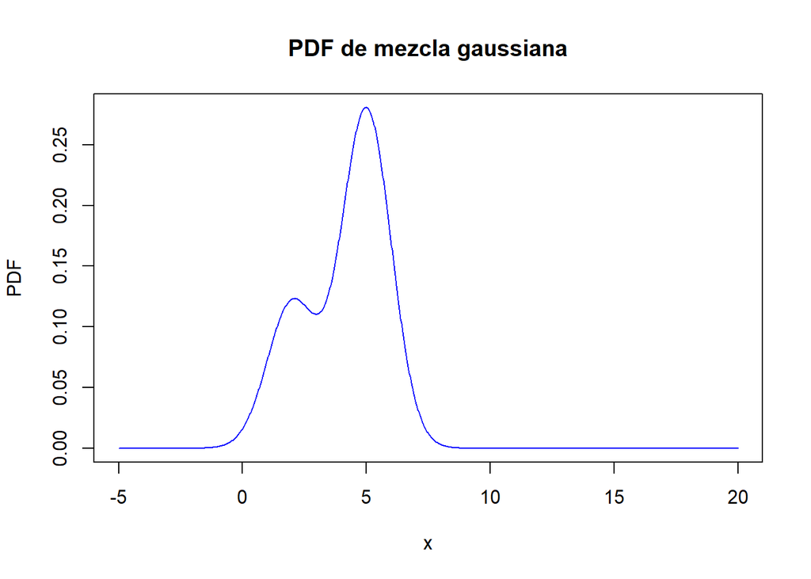

```r
x <- seq(-5, 20, length.out = 1000)

plot(x, GM(x, 2, 1, 5, 1, 0.3), type = "l", col = "blue", xlab = "x", ylab = "PDF",
     main = "PDF de mezcla gaussiana")
```

Observamos claramente cómo tenemos una mezcla gaussiana.

## Ejercicio 5.2

**Enunciado**

Inicialmente, solo observamos los datos de longitud y asumimos que las ubicaciones de longitud son i.i.d. que siguen un modelo de mezcla Gaussiana. Estima los cinco parámetros de la mezcla gaussiana utilizando los 1000 valores observados de longitud. Puedes hacer esto numéricamente en R con la función **optim**. Grafica la mezcla Gaussiana ajustada sobre el histograma de los datos de longitud.

Para encontrar una buena punto inicial para los parámetros, simplemente puedes observar el histograma de los datos y tratar de adivinar la ubicación de las medias $\mu_1$ y $\mu_2$. Una suposición inicial para $w$ puede ser la proporción del tamaño de los dos grupos de datos (o usar $w = 0.5$ como suposición inicial). También puedes probar diferentes valores iniciales y reportar los resultados con la menor log-verosimilitud negativa.

Dado que hay muchos parámetros, la optimización puede llevar mucho tiempo y es probable que debas aumentar el número máximo de iteraciones del algoritmo; de lo contrario, saldrá antes de alcanzar un buen óptimo. Puedes hacerlo con **control** = list(maxit = 10000)} en la función **optim**. Probablemente también habrá muchos warnings, principalmente porque los parámetros deben estar restringidos, especialmente $w$. Puedes ignorar los warnings.

**Resolución**

Procedemos igual que en otros ejercicios, particularizando para nuestra nueva función de densidad de probabilidad.

```r
mllk_GM <- function(params, data) {
  data <- data
  mean1 <- params[1]
  sd1 <- params[2]
  mean2 <- params[3]
  sd2 <- params[4]
  w <- params[5]

  return(-sum(log(GM(x = data, mu1 = mean1, sigma1 = sd1, mu2 = mean2, sigma2 = sd2, w = w))))
}
```

```r
long <- na.omit(quakes$long) # quito los NA para que no haya problemas

paramsGMlong <- optim(c(166, 3, 183, 2, 0.5), f = mllk_GM, data = long, method = c("Nelder-Mead"), control = list(maxit = 10000))$par
names(paramsGMlong) <- c("mean_1", "sd_1", "mean_2", "sd_2", "w")
print(paramsGMlong)
```

```
     mean_1        sd_1      mean_2        sd_2           w
168.2389530   1.9403078 182.3427645   2.1551014   0.2041146
```

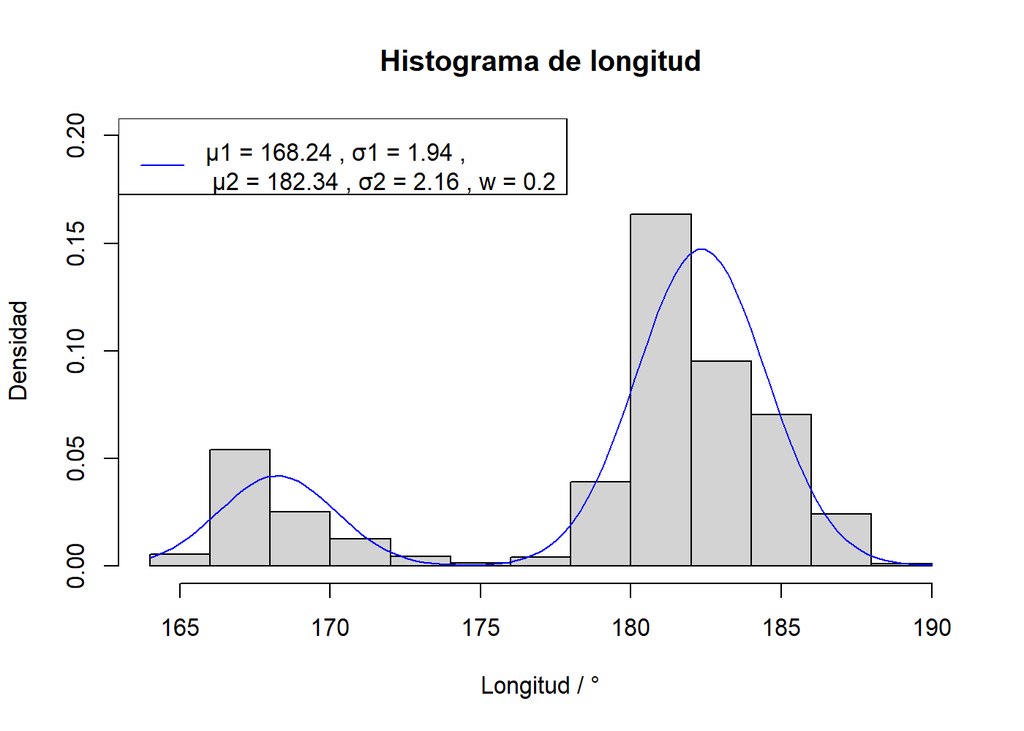

```r
hist(long, breaks = 10, probability = TRUE, ylim = c(0, 0.2), xlab = "Longitud / °", main = "Histograma de longitud", ylab = "Densidad")
curve(GM(x, paramsGMlong[1], paramsGMlong[2], paramsGMlong[3], paramsGMlong[4], paramsGMlong[5]), add = TRUE, col = "blue")
legend("topleft", legend = paste("µ1 =", round(paramsGMlong[1], 2), ", σ1 =", round(paramsGMlong[2], 2), ",\n µ2 =", round(paramsGMlong[3], 2), ", σ2 =", round(paramsGMlong[4], 2), ", w =", round(paramsGMlong[5], 2)), col = "blue", lty = 1)
```

## Ejercicio 5.3

**Enunciado**

Considera ahora otro modelo en el que las ubicaciones de longitud son independientes y distribuidas de manera gaussiana $N(\mu, \sigma^2)$. Ajusta este modelo a los datos observados de longitud.

**Resolución**

```r
mllk_norm <- function(params, data) {
  mean <- params[1]
  sd <- params[2]
  -sum(dnorm(data, mean = mean, sd = sd, log = TRUE))
}
```

```r
paramslong <- optim(c(150, 20), f = mllk_norm, data = long, method = c("Nelder-Mead"))$par
names(paramslong) <- c("mean", "sd")
print(paramslong)
```

```
      mean         sd
179.463147   6.067513
```

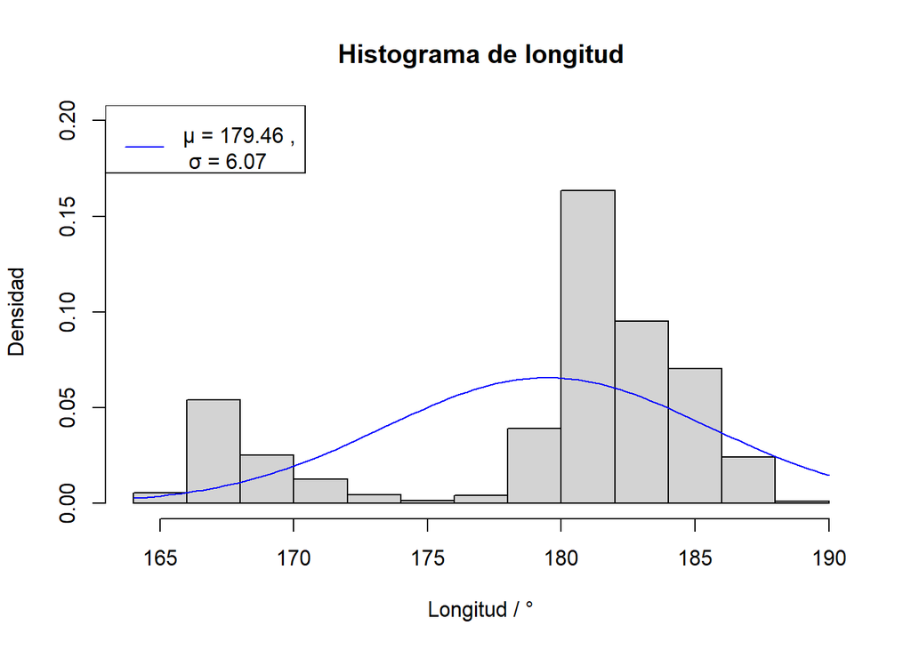

```r
hist(long, breaks = 10, probability = TRUE, ylim = c(0, 0.2), xlab = "Longitud / °", ylab = "Densidad", main = "Histograma de longitud")
curve(dnorm(x, mean = paramslong[1], sd = paramslong[2]), add = TRUE, col = "blue")
legend("topleft", legend = paste("µ =", round(paramslong[1], 2), ",\n σ =", round(paramslong[2], 2)), col = "blue", lty = 1)
```

Vemos cómo resulta a simple vista menos preciso ajustar los datos con una sola gaussiana que con la mezcla gaussiana vista anteriormente.

## Ejercicio 5.4

**Enunciado**

Calcula los valores de AIC y BIC para el modelo gaussiano simple y el modelo de mezcla gaussiana para lso datos de longitud. ¿Qué modelo debería seleccionarse?

**Resolución**

El criterio de información de Akaike (AIC) se basa en una estimación de la divergencia Kullback-Leibler (KL) entre nuestro modelo $\mathcal{M}$ y el verdadero modelo de generación de datos $\mathcal{M}^*$. Si nuestro modelo tiene $k$ parámetros, entonces:

$$AIC = -2 \log(\mathcal{L}) + 2k$$

Elegiremos el modelo que obtiene el valor AIC más bajo entre los candidatos.

```r
k_mix <- length(paramsGMlong)
aic_mix <- -2 * sum(log(GM(long, paramsGMlong[1], paramsGMlong[2], paramsGMlong[3], paramsGMlong[4], paramsGMlong[5]))) + 2 * k_mix

k_norm <- length(params)
aic_norm <- -2 * sum(dnorm(long, params[1], params[2], log = TRUE)) + k_norm

aic <- c(aic_mix, aic_norm)
names(aic) <- c("AIC Mezcla", "AIC Normal")
print(aic)
```

```
 AIC Mezcla  AIC Normal
   5349.805 9869737.547
```

```r
if (aic_mix < aic_norm) {
  print("Se selecciona el modelo de mezcla.")
} else {
  print("Se selecciona el modelo gaussiano usual.")
}
```

```
[1] "Se selecciona el modelo de mezcla."
```

El Criterio de Información Bayesiana (BIC) es similar al AIC, pero ahora aproxima la distribución posterior del modelo $\mathcal{M}$ dado los datos observados, utilizando una distribución previa uniforme sobre los modelos.

$$BIC = -2 \log(\mathcal{L}) + k
\log(n)$$
Elegiremos el modelo que obtiene el valor BIC más bajo entre los candidatos.

```r
n <- length(long)

k_mix <- length(paramsGMlong)
bic_mix <- -2 * sum(log(GM(long, paramsGMlong[1], paramsGMlong[2], paramsGMlong[3], paramsGMlong[4], paramsGMlong[5]))) + k_mix * log(n)

k_norm <- length(params)
bic_norm <- -2 * sum(dnorm(long, params[1], params[2], log = TRUE)) + k_norm * log(n)

bic <- c(bic_mix, bic_norm)
names(bic) <- c("BIC Mezcla", "BIC Normal")
print(bic)
```

```
 BIC Mezcla  BIC Normal
   5374.344 9869749.363
```

```r
if (bic_mix < bic_norm) {
  print("Se selecciona el modelo de mezcla.")
} else {
  print("Se selecciona el modelo gaussiano usual.")
}
```

```
[1] "Se selecciona el modelo de mezcla."
```

## Ejercicio 5.5

**Enunciado**

Repite el procedimiento de ajuste anterior para los datos de latitud y profundidad, y realiza la selección de modelo como de costumbre usando AIC y BIC. ¿Qué modelo debería usarse?

**Resolución**

Repetimos el mismo proceso que antes pero con latitud y profundidad.

```r
lat <- na.omit(quakes$lat)
depth <- na.omit(quakes$depth)
```

```r
paramsGMlat <- optim(c(-20, 3, -15, 2, 0.5), f = mllk_GM, data = lat, method = c("Nelder-Mead"), control = list(maxit = 10000))$par
names(paramsGMlat) <- c("mean_1", "sd_1", "mean_2", "sd_2", "w")

paramslat <- optim(c(-20, 3), f = mllk_norm, data = lat, method = c("Nelder-Mead"))$par
names(paramslat) <- c("mean", "sd")

paramsGMdepth <- optim(c(100, 30, 550, 10, 0.5), f = mllk_GM, data = depth, method = c("Nelder-Mead"), control = list(maxit = 10000))$par
names(paramsGMlat) <- c("mean_1", "sd_1", "mean_2", "sd_2", "w")

paramsdepth <- optim(c(-20, 3), f = mllk_norm, data = depth, method = c("Nelder-Mead"))$par
names(paramsdepth) <- c("mean", "sd")
```

### AIC. Latitud

```r
k_mix <- length(paramsGMlat)
aic_mix <- -2 * sum(log(GM(lat, paramsGMlat[1], paramsGMlat[2], paramsGMlat[3], paramsGMlat[4], paramsGMlat[5]))) + 2 * k_mix

k_norm <- length(paramslat)
aic_norm <- -2 * sum(dnorm(lat, paramslat[1], paramslat[2], log = TRUE)) + k_norm

aic <- c(aic_mix, aic_norm)
names(aic) <- c("AIC Mezcla", "AIC Normal")
print(aic)
```

```
AIC Mezcla AIC Normal
  5995.200   6069.236
```

```r
if (aic_mix < aic_norm) {
  print("Se selecciona el modelo de mezcla.")
} else {
  print("Se selecciona el modelo gaussiano usual.")
}
```

```
[1] "Se selecciona el modelo de mezcla."
```

### AIC. Profundidad

```r
k_mix <- length(paramsGMdepth)
aic_mix <- -2 * sum(log(GM(depth, paramsGMdepth[1], paramsGMdepth[2], paramsGMdepth[3], paramsGMdepth[4], paramsGMdepth[5]))) + 2 * k_mix

k_norm <- length(paramsdepth)
aic_norm <- -2 * sum(dnorm(depth, paramsdepth[1], paramsdepth[2], log = TRUE)) + k_norm

aic <- c(aic_mix, aic_norm)
names(aic) <- c("AIC Mezcla", "AIC Normal")
print(aic)
```

```
AIC Mezcla AIC Normal
  12902.87   13585.44
```

```r
if (aic_mix < aic_norm) {
  print("Se selecciona el modelo de mezcla.")
} else {
  print("Se selecciona el modelo gaussiano usual.")
}
```

```
[1] "Se selecciona el modelo de mezcla."
```

### BIC. Latitud

```r
n <- length(lat)

k_mix <- length(paramsGMlat)
bic_mix <- -2 * sum(log(GM(lat, paramsGMlat[1], paramsGMlat[2], paramsGMlat[3], paramsGMlat[4], paramsGMlat[5]))) + k_mix * log(n)

k_norm <- length(paramslat)
bic_norm <- -2 * sum(dnorm(lat, paramslat[1], paramslat[2], log = TRUE)) + k_norm * log(n)

bic <- c(bic_mix, bic_norm)
names(bic) <- c("BIC Mezcla", "BIC Normal")
print(bic)
```

```
BIC Mezcla BIC Normal
  6019.739   6081.051
```

```r
if (bic_mix < bic_norm) {
  print("Se selecciona el modelo de mezcla.")
} else {
  print("Se selecciona el modelo gaussiano usual.")
}
```

```
[1] "Se selecciona el modelo de mezcla."
```

### BIC. Profundidad

```r
n <- length(depth)

k_mix <- length(paramsGMdepth)
bic_mix <- -2 * sum(log(GM(depth, paramsGMdepth[1], paramsGMdepth[2], paramsGMdepth[3], paramsGMdepth[4], paramsGMdepth[5]))) + k_mix * log(n)

k_norm <- length(paramsdepth)
bic_norm <- -2 * sum(dnorm(depth, paramsdepth[1], paramsdepth[2], log = TRUE)) + k_norm * log(n)

bic <- c(bic_mix, bic_norm)
names(bic) <- c("BIC Mezcla", "BIC Normal")
print(bic)
```

```
BIC Mezcla BIC Normal
  12927.41   13597.26
```

```r
if (bic_mix < bic_norm) {
  print("Se selecciona el modelo de mezcla.")
} else {
  print("Se selecciona el modelo gaussiano usual.")
}
```

```
[1] "Se selecciona el modelo de mezcla."
```